# Start Modeling with R — Notes

```r
mean(distance, data = trebuchet)
```

```
## [1] 594.8
```

### Wednesday May 15, 2013

## Review of “Formulas”

### Sample Statistics

```r
mean(mpg, data = EPA)
```

```
## [1] 20.38
```

```r
mean(mpg ~ drive, data = EPA)
```

```
##     4     R
## 12.83 21.08
```

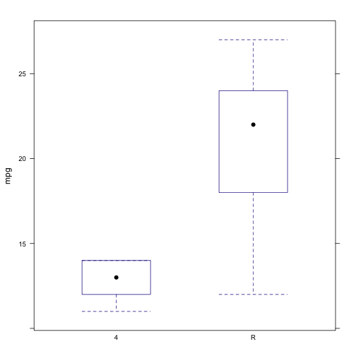

```r
bwplot(mpg ~ drive, data = EPA)
```

### What's a Formula in R?

Just as there are numbers and character strings and arrays, etc., there is a special kind of thing in R called a **formula**.

- A formula is a way of stating a relationship among variables that doesn't evaluate things numerically: it's a symbolic statement.
- Programmers, like us when building `mosaic` write functions that use the symbolic information in the formula. (It's in the form of a parse tree, for those who care about such things.)
- A `data=` argument provides a way to specify the context in which the specific values of thesymbolic quantities in the formula are to be found.

Students, by and large, don't know enough about computation to find the formula funny.

### The operations in formulas

`+`, `-`, `*`, `&`, `|` have a metaphorical meaning, which we'll talk about. It's pretty consistent across major R features.

Can also use operations such as `==`, `>`, `sin()`, `sqrt()`, `log()`, etc.

### One variable goes to the right of the Tilde `~`

This is odd at first.

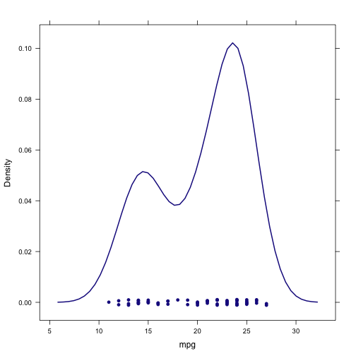

```r
densityplot(~mpg, data = EPA)
```

```r
tally(~drive, data = EPA)
```

```
##
##     4     R Total
##     6    65    71
```

```r
mean(~mpg, data = EPA)
```

```
## [1] 20.38
```

We've overridden this for some basic operators (mean, sd, etc.) for compatibility with the fundamental operators that didn't use formulas. That's why you can write

```r
mean(mpg, data = EPA)
```

```
## [1] 20.38
```

I would be inclined to change `histogram()` etc. in a similar way, but that isn't our software.

## Models and Fitting

A model is a “representation for a purpose.” Some examples of common purposes:

- make a prediction
- describe a system
- describe a relationship in the context of other relationships.

An early step in building a model should be recognizing what the purpose is. This is not always what we do in teaching, where we are tempted to talk about methods and definitions and proofs.

It can help to have a specific context so that a specific purpose makes sense.

### The Trebuchet

A medieval siege engine for throwing heavy objects long distances. [Video of a trebuchet launch at Warwick Castle](http://www.youtube.com/watch?v=thiTa8wfZsc)

Trebuchets have parameters e.g.:

- lever length
- sling length
- counterweight
- projectile weight
- lever angle

What would be the purpose of building a mathematical model of a trebuchet?

- NOT: to scare the enemy with mathematics
- To predict how far a given object will be thrown
- To figure out how to configure the trebuchet to get a given object on target
- To decide what sort of object can be thrown to a given target with a given configuration.

```r
require(fastR)
```

Let's build a mathematical model of a trebuchet. Here are some variables on which we have data:

```r
names(trebuchet)
```

```
## [1] "object"       "projectileWt" "counterWt"    "distance"
## [5] "form"
```

Any ideas?

- What form should the function take?
- What should the parameters be?

Let's plot some data:

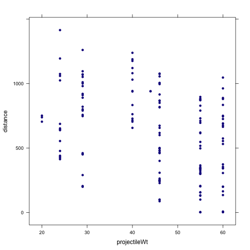

```r
xyplot(distance ~ projectileWt, data = trebuchet)
```

Making our function and adding it to the previous plot

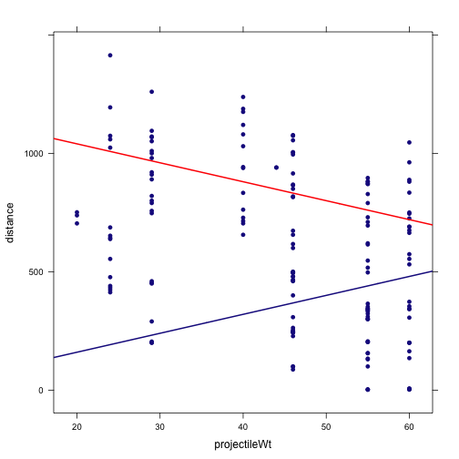

```r
f = makeFun(8 * projectileWt ~ projectileWt)
xyplot(distance ~ projectileWt, data = trebuchet)
plotFun(f(wt) ~ wt, add = TRUE)
g <- makeFun(1200 - 8 * projectileWt ~ projectileWt)
plotFun(g(wt) ~ wt, add = TRUE, col = "red")
```

Residuals …

```r
myresids = with(trebuchet, distance - g(projectileWt))
sum(myresids^2)
```

```
## [1] 25325443
```

```r
mean(myresids)
```

```
## [1] -243.3
```

Rs best guess:

```r
myModel = lm(distance ~ projectileWt, data = trebuchet)
myModel
```

```
##
## Call:
## lm(formula = distance ~ projectileWt, data = trebuchet)
##
## Coefficients:
##  (Intercept)  projectileWt
##       1071.1         -10.5
```

An example model:

```r
dist = makeFun(counterWt - 5 * projectileWt ~ counterWt & projectileWt)
```

Let's see what this looks like:

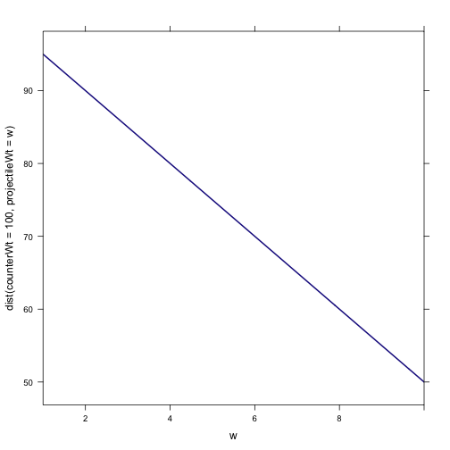

```r
plotFun(dist(counterWt = 100, projectileWt = w) ~ w, w.lim = range(1, 10))
```

What weight projectile to throw the thing 70 units?

It's a function of two variables:

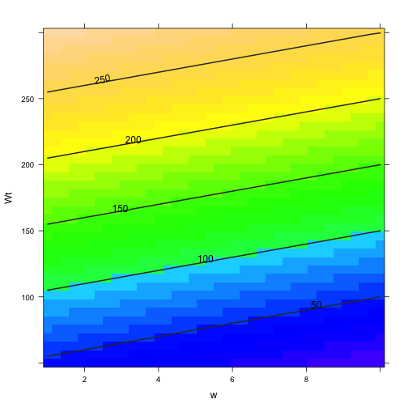

```r
plotFun(dist(counterWt = Wt, projectileWt = w) ~ w & Wt, w.lim = range(1, 10),
    Wt.lim = range(50, 300))
```

This sort of function could be used to decide what the counterweight and projectile weight can be to go a certain distance, letting us pick from a set of projectiles. Or perhaps to decide whether it's better to move the trebuchet or to change the counterweight.

### QUESTIONS

- How do we get a model that is informed by the data?
- Does it have to be a straight-line model? What sorts of functions are allowed?
- Making a model with categorical inputs?